# Ford GoBike Analysis

## by Sandy Ibrahim

## Investigation Overview

> The goal of this investigation is to discover what will lead to a high usage of bike using the variables in this dataset such as gender, user type, age, weekend, weekdays or peak hours per day.

## Dataset Overview

> Bay Wheels is a regional public bicycle sharing system in California's San Francisco Bay Area.it is the first regional and large-scale bicycle sharing system deployed in California and on the West Coast of the United States. It was established as Bay Area Bike Share in August 2013. As of January 2018, the Bay Wheels system had over 2,600 bicycles in 262 stations across San Francisco, East Bay and San Jose. In June 2017 the system was officially re-launched as Ford GoBike in a partnership with Ford Motor Company. After Motivate's acquisition by Lyft, the system was renamed to Bay Wheels in June 2019. The system is expected to expand to 7,000 bicycles around 540 stations in San Francisco, Oakland, Berkeley, Emeryville, and San Jose.

> In this project, we explore data related to bike bike share systems for San Francisco Bay Area in the United States on the month of February 2019. This document explores a dataset containing 183412 rows and 16 columns.

## Number of daily trips per hour

> The peak hours of the day is from 7 to 10 AM and from 4 to 7 PM. Also, the lowest number of bikes are rented during 12 AM to 5 AM. Therefore we assumed that the most bikes are rented by people for mobility to and from work.

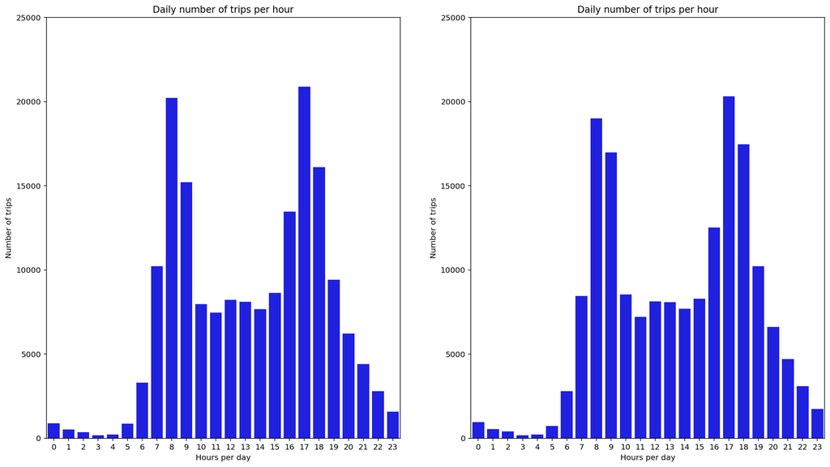

## The bike riders age

> The highest riders ages are between the age of 20 to 40 years old.

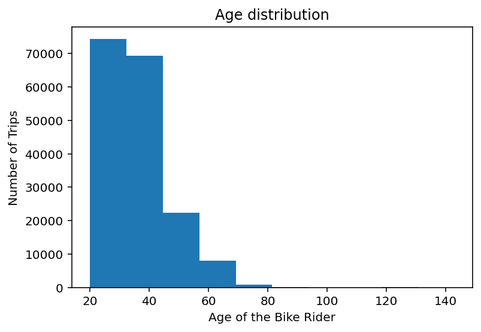

## Number of Users Type

> The comparison between number of Customers and Subscribers of Ford Bike Data.We can clearly see that the subscribers are more than the customers in our the dataset.

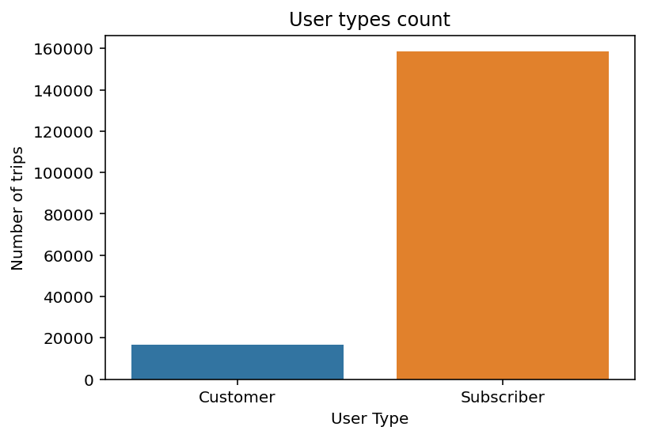

## Number of members gender

> The comparison between number of bikes rented by males versus female. The males are renting bikes more than the females in the our dataset with 75% for males and 23% for females.

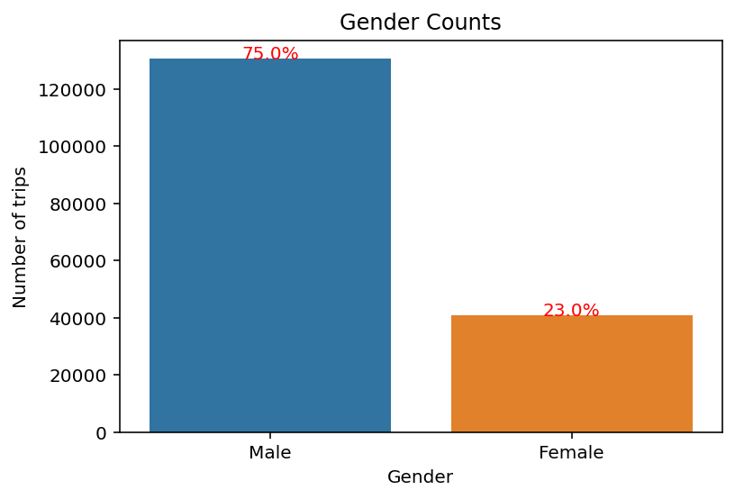

## Number of rented bikes per weekdays

> The number of bikes rented on the weekdays are higher than the ones on weekends that mean the weekdays are more crowded than the weekends, therefore we assumed that the most bikes are rented by people for mobility to and from work.

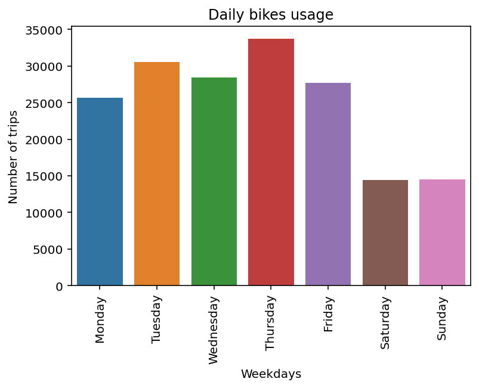

## The correlation between trip duration & bike rider age

> The highest duration of trips around the age of 30 years old.

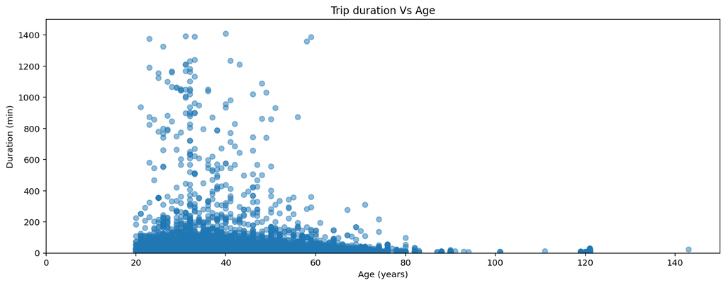

## The correlation between member gender & user type

> The number of subscribed males are more than the subscribed females. Also, the number of customer males are more than the customer females.

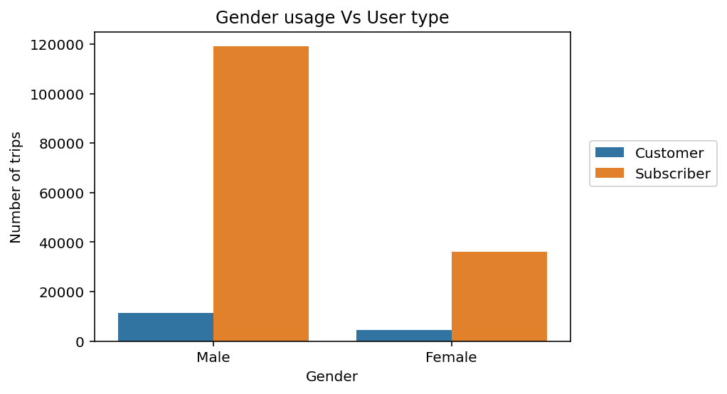

# The correlation between daily bikes usage and day timing

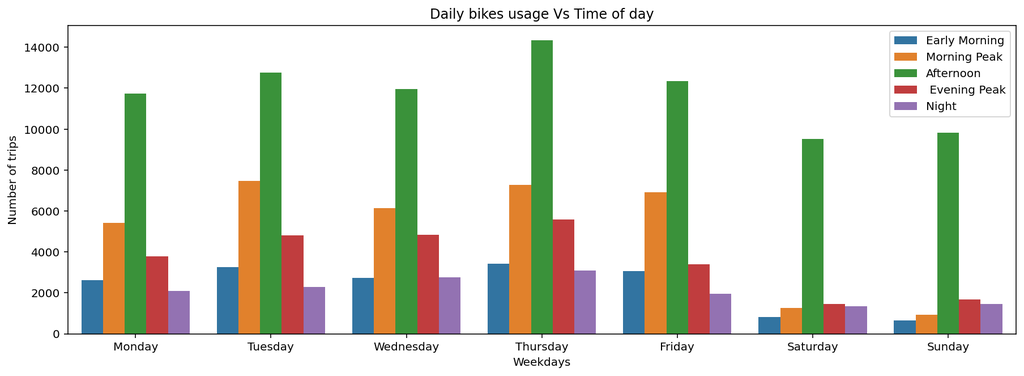

## The correlation between trip duration, age of bike rider & user type

> The highest duration trip is for a subscriber and the age between 20 to 40 years old.

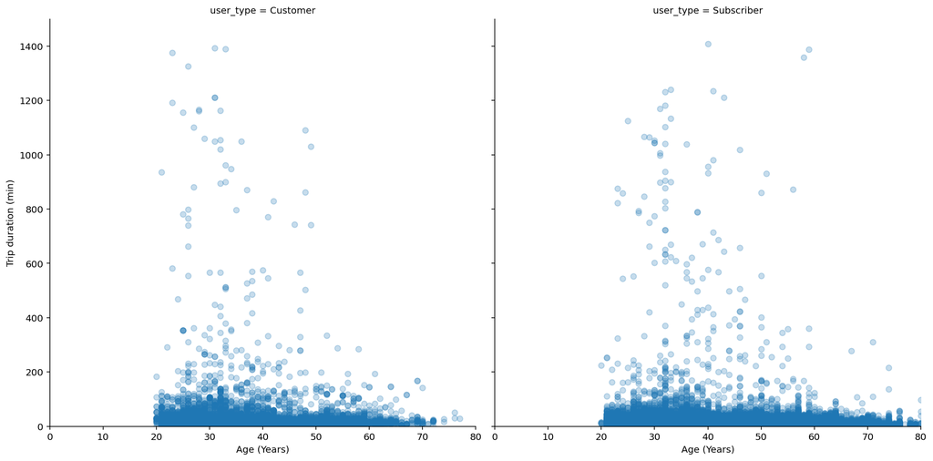

## The correlation between day time, rider gender & rider age

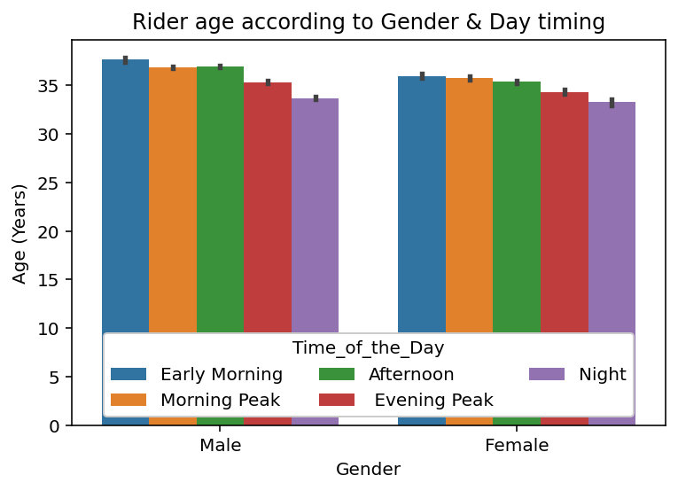